# Patterns for Regression Models

J Faleiro

April 10, 2016

# Required libraries

```r
if (!require("pacman")) install.packages("pacman")
pacman::p_load(datasets, UsingR, reshape, ggplot2, manipulate, dplyr, GGally, stats, rgl, car)
```

# Why Statisticians Love Confusing Synonyms?

Various names for the same thing: variable independence

| Independent Variable | Dependent Variable |
| --- | --- |
| X axis | Y axis |
| Predictor | Outcome |
| Predictor | Predicted |
| Regressor | Outcome |

The function `lm` needs a formula of the form dependent ~ independent (or predicted ~ predictor).

# Basic Least Squares

### Finding Least Squares

Finding the least (i.e. that minimizes) squares (to ensure points below and above the line are treated the same) is to find the minimum value of the following equation:

$\sum_{i=1}^{n} (Y_i - \mu)^2$

```r
y <- c(0.8, 0.47, 0.51, 0.73, 0.36, 0.58, 0.57, 0.85, 0.44, 0.42)
leastSquares <- function(mu) { sum((y - mu)^2) }
optimize(leastSquares, interval=c(-100, 100), maximum=FALSE)
```

```
## $minimum
## [1] 0.573
##
## $objective
## [1] 0.25401
```

What in theory should match $\bar{Y}$:

```r
mean(y)
```

```
## [1] 0.573
```

What if we get something a bit more elaborate:

$\sum_{i=1}^{n} w_i(x_i - \mu)^2$

What would be the value of $\mu$ that would minimize the least square equation?

```r
x <- c(0.18, -1.54, 0.42, 0.95)
w <- c(2, 1, 3, 1)
leastSquares <- function(mu) { sum(w*(x - mu)^2) }
optimize(leastSquares, interval=c(-100, 100), maximum=FALSE)
```

```
## $minimum
## [1] 0.1471429
##
## $objective
## [1] 3.716543
```

### Heights of Parents and Children

```r
library(UsingR); data(galton); library(reshape)
describe(galton)
```

```
## galton
##
##  2  Variables      928  Observations
## ---------------------------------------------------------------------------
## child
##       n missing  unique    Info    Mean     .05     .10     .25     .50
##     928       0      14    0.98   68.09    64.2    64.2    66.2    68.2
##     .75     .90     .95
##    70.2    71.2    72.2
##
##           61.7 62.2 63.2 64.2 65.2 66.2 67.2 68.2 69.2 70.2 71.2 72.2 73.2
## Frequency    5    7   32   59   48  117  138  120  167   99   64   41   17
## %            1    1    3    6    5   13   15   13   18   11    7    4    2
##           73.7
## Frequency   14
## %            2
## ---------------------------------------------------------------------------
## parent
##       n missing  unique    Info    Mean     .05     .10     .25     .50
##     928       0      11    0.97   68.31    65.5    65.5    67.5    68.5
##     .75     .90     .95
##    69.5    70.5    71.5
##
##           64 64.5 65.5 66.5 67.5 68.5 69.5 70.5 71.5 72.5 73
## Frequency 14   23   66   78  211  219  183   68   43   19  4
## %          2    2    7    8   23   24   20    7    5    2  0
## ---------------------------------------------------------------------------
```

```r
head(galton)
```

```
##   child parent
## 1  61.7   70.5
## 2  61.7   68.5
## 3  61.7   65.5
## 4  61.7   64.5
## 5  61.7   64.0
## 6  62.2   67.5
```

```r
long <- melt(galton)
describe(long)
```

```
## long
##
##  2  Variables      1856  Observations
## ---------------------------------------------------------------------------
## variable
##       n missing  unique
##    1856       0       2
##
## child (928, 50%), parent (928, 50%)
## ---------------------------------------------------------------------------
## value
##       n missing  unique    Info    Mean     .05     .10     .25     .50
##    1856       0      25    0.99    68.2    64.2    65.2    67.2    68.5
##     .75     .90     .95
##    69.5    71.2    72.2
##
## lowest : 61.7 62.2 63.2 64.0 64.2, highest: 72.2 72.5 73.0 73.2 73.7
## ---------------------------------------------------------------------------
```

```r
head(long)
```

```
##   variable value
## 1    child  61.7
## 2    child  61.7
## 3    child  61.7
## 4    child  61.7
## 5    child  61.7
## 6    child  62.2
```

Plot distributions of children and parents, heights in inches.

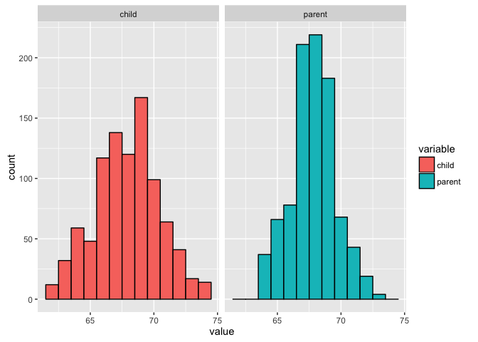

```r
ggplot(long, aes(x=value, fill=variable)) +
    geom_histogram(colour='black', binwidth=1) +
    facet_grid(. ~ variable)
```

Comparing children and (average over the pair of) parents heights:

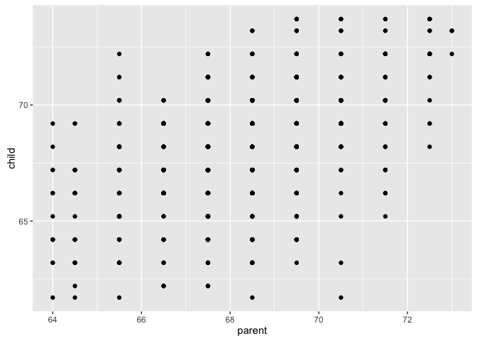

```r
ggplot(galton, aes(x=parent, y=child)) +
    geom_point()
```

A bad plot, no indication of when a point is plotted over it a number of times. We can do a bit better by using `plot` and `jitter`:

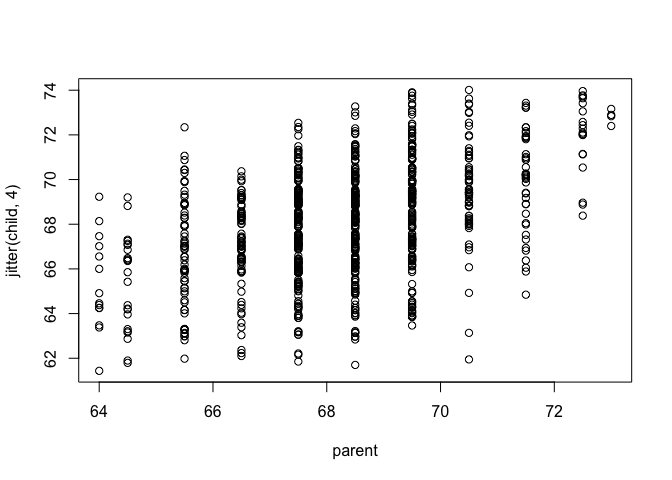

```r
plot(jitter(child, 4) ~ parent, galton)
```

The regression line of children ~ parent can be calculated by `lm`. The function `lm` needs a formula of the form dependent ~ independent (or predicted ~ predictor).

```r
regrline <- lm(child ~ parent, galton)
summary(regrline)
```

```
##
## Call:
## lm(formula = child ~ parent, data = galton)
##
## Residuals:
##     Min      1Q  Median      3Q     Max
## -7.8050 -1.3661  0.0487  1.6339  5.9264
##
## Coefficients:
##             Estimate Std. Error t value Pr(>|t|)
## (Intercept) 23.94153    2.81088   8.517   <2e-16 ***
## parent       0.64629    0.04114  15.711   <2e-16 ***
## ---
## Signif. codes:  0 '***' 0.001 '**' 0.01 '*' 0.05 '.' 0.1 ' ' 1
##
## Residual standard error: 2.239 on 926 degrees of freedom
## Multiple R-squared:  0.2105, Adjusted R-squared:  0.2096
## F-statistic: 246.8 on 1 and 926 DF,  p-value: < 2.2e-16
```

The first thing we can notice is that the mean of the residuals of regrline is close to zero:

```r
mean(regrline$residuals)
```

```
## [1] -2.359884e-15
```

And also the correlation between residuals and predictors will be close to zero, i.e. they are uncorrelated.

```r
cov(regrline$residuals, galton$parent)
```

```
## [1] -1.790153e-13
```

The intercept $\beta_0$ is the first element of regrline$coef:

```r
regrline$coef[1]
```

```
## (Intercept)
##    23.94153
```

The slope $\beta_1$ is the second element of regrline$coef:

```r
regrline$coef[2]
```

```
##    parent
## 0.6462906
```

A coefficient will be within 2 standard errors of its estimate about 95% of the time. This means the slope of our regression is significantly different than either 0 or 1 since (.64629) +/- (2*.04114) is near neither 0 nor 1.

We can see that the coeficient (multiplier) of parents to children is given by $0.64629 \pm 2 * 0.04114$

And we can add the regression line to the original plot:

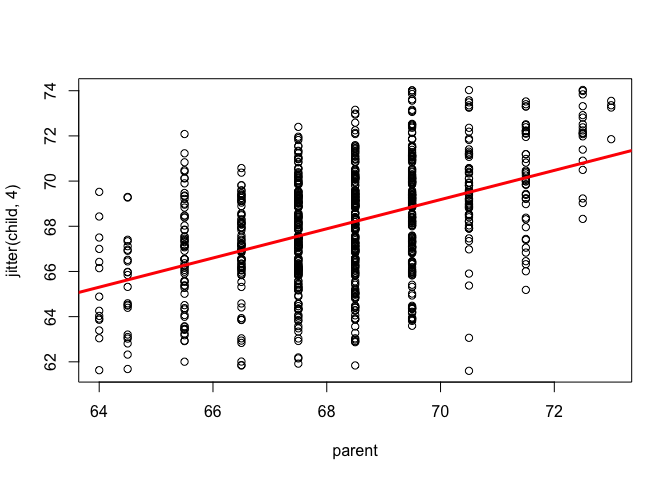

```r
plot(jitter(child, 4) ~ parent, galton)
abline(regrline, lwd=3, col='red')
```

We can get a plot with the same information using `ggplot2`:

```r
freqData <- as.data.frame(table(galton$child, galton$parent))
names(freqData) <- c("child", "parent", "freq")
freqData$child <- as.numeric(as.character(freqData$child))
freqData$parent <- as.numeric(as.character(freqData$parent))
head(freqData)
```

```
##   child parent freq
## 1  61.7     64    1
## 2  62.2     64    0
## 3  63.2     64    2
## 4  64.2     64    4
## 5  65.2     64    1
## 6  66.2     64    2
```

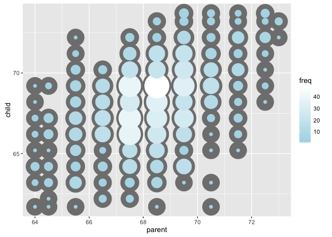

```r
ggplot(filter(freqData, freq > 0), aes(x = parent, y = child)) +
    scale_size(range = c(2, 20), guide = "none" ) +
    geom_point(colour="grey50", aes(size = freq+20, show_guide = FALSE)) +
    geom_point(aes(colour=freq, size = freq)) +
    scale_colour_gradient(low = "lightblue", high="white")
```

We can calculate the optimal linear regression:

```r
lm(I(child - mean(child)) ~ I(parent - mean(parent)) -1, data=galton)
```

```
##
## Call:
## lm(formula = I(child - mean(child)) ~ I(parent - mean(parent)) -
##     1, data = galton)
##
## Coefficients:
## I(parent - mean(parent))
##                   0.6463
```

Shows the value of $\beta$ through which you minimize the mean square error given by $\sum_{i=1}^{n} {(Y_i - \beta X_i)}^2$, what is 0.646

That’s how it looks like graphically:

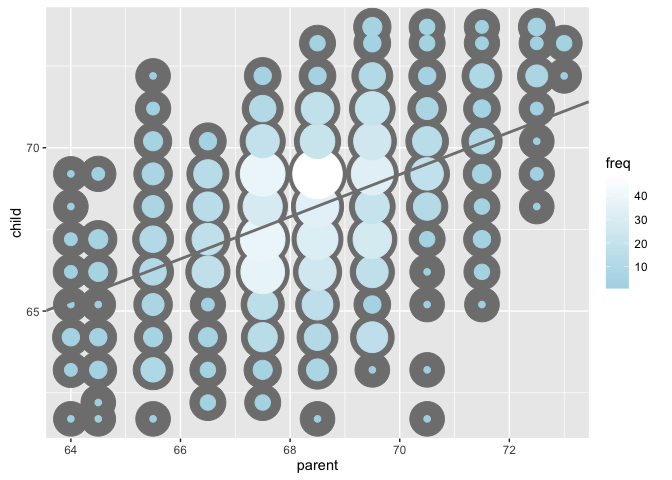

```r
lm1 <- lm(galton$child ~ galton$parent)
ggplot(filter(freqData, freq > 0), aes(x = parent, y = child)) +
    scale_size(range = c(2, 20), guide = "none" ) +
    geom_point(colour="grey50", aes(size = freq+20, show_guide = FALSE)) +
    geom_point(aes(colour=freq, size = freq)) +
    scale_colour_gradient(low = "lightblue", high="white") +
    geom_abline(intercept = coef(lm1)[1], slope = coef(lm1)[2], size = 1, colour = grey(.5))
```

### Linear Least Squares

```r
y <- galton$child
x <- galton$parent
beta1 <- cor(y, x) * sd(y)/sd(x)
beta0 <- mean(y) - beta1 * mean(x)
c(beta0, beta1)
```

```
## [1] 23.9415302  0.6462906
```

```r
coef(lm(y ~ x))
```

```
## (Intercept)           x
##  23.9415302   0.6462906
```

The coeficients are exactly beta0 and beta1 we calculated above.

If we reverse the outcome/predictor relationships, we switch the model:

```r
beta1 <- cor(y, x) * sd(x)/sd(y)
beta0 <- mean(x) - beta1 * mean(y)
rbind(c(beta0, beta1), coef(lm(x ~ y)))
```

```
##      (Intercept)         y
## [1,]    46.13535 0.3256475
## [2,]    46.13535 0.3256475
```

Same values.

Now, checking $\beta_1$ and $\beta_0$ when a regression is through the origin $(x=0, y=0)$.

If through the origin, $\beta_0 = 0$. Now $\beta_1$:

```r
yc <- y - mean(y)
xc <- x - mean(x)
beta1 <- sum(yc * xc) / sum(xc ^ 2)
c(beta1, coef(lm(y ~ x))[2])
```

```
##                   x
## 0.6462906 0.6462906
```

They both yield the same result. You get the same slope if you use yc and xc, as long as you subtract the intercept (-1):

```r
lm(formula = yc ~ xc -1)
```

```
##
## Call:
## lm(formula = yc ~ xc - 1)
##
## Coefficients:
##     xc
## 0.6463
```

You can also use normalized $X_i$ and $Y_i$ and the slope of $lm(Zy_i, Zx_i)$ will be the same as $cor(Y_i,X_i)$ and the same as $cor(Zy_i, Zx_i)$:

```r
yn <- (y - mean(y))/sd(y) # normalized Y
xn <- (x - mean(x))/sd(x) # normalized X
c(cor(y, x), cor(yn, xn), coef(lm(yn ~ xn))[2])
```

```
##                            xn
## 0.4587624 0.4587624 0.4587624
```

The best way to add a linear regression line to a plot is by adding a layer `geom_smooth` to a plot, using `lm` as a method and `y ~ x` as the formula (what is the default):

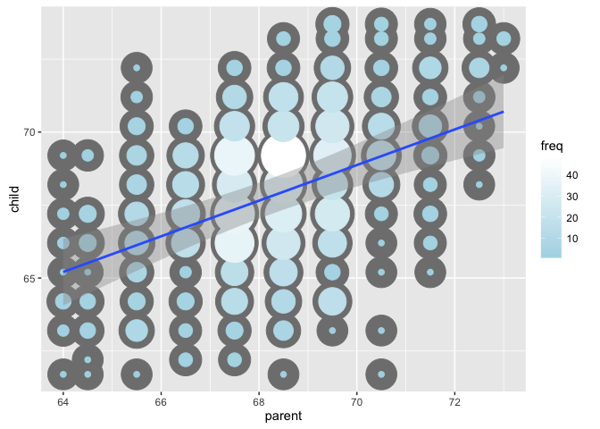

```r
ggplot(filter(freqData, freq > 0), aes(x = parent, y = child)) +
    scale_size(range = c(2, 20), guide = "none" ) +
    geom_point(colour="grey50", aes(size = freq+20, show_guide = FALSE)) +
    geom_point(aes(colour=freq, size = freq)) +
    scale_colour_gradient(low = "lightblue", high="white") +
    geom_smooth(method='lm', formula=y~x)
```

You can see that a confidence interval (shaded area) is given for free with a `geom_smooth` layer. The statistical uncertainty is added automatically.

### Regression to the mean

Y is related to son’s height and X to the father’s height, both normalized:

```r
y <- (father.son$sheight - mean(father.son$sheight)) / sd(father.son$sheight)
x <- (father.son$fheight - mean(father.son$fheight)) / sd(father.son$fheight)
rho <- cor(x, y)
```

Since x and y are normalized:

```r
c(sd(x), sd(x))
```

```
## [1] 1 1
```

```r
c(mean(x), mean(y))
```

```
## [1] -1.627998e-15  9.259712e-16
```

The mean is almost zero.

We will plot with a few assumptions:

- we set x and y limits as (-4,4) - since this is in SDs, the chance of something falling beyond that (4 SDs away from the mean) is dim
- the line `geom_abline(intercept=0, slope=1)` is the identity line, what would be the regression line if no noise, i.e. X and Y perfectly correlated.
- the line `geom_abline(intercept=0, slope=rho, size=2)`, in red, is the line showing son’s height as the outcome and parent’s height as the predictor
- the line `geom_abline(intercept=0, slope=1/rho, size=2)` is the line showing son’s height as the predictor and parent’s height as the outcome

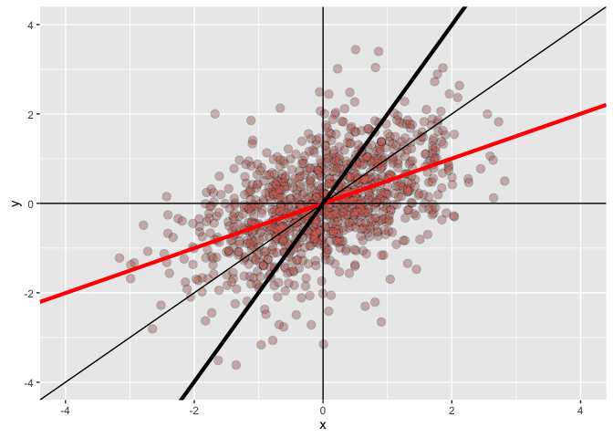

```r
ggplot(data.frame(x-x, y=y), aes(x = x, y = y)) +
    geom_point(colour="black", alpha=0.2, size=3) +
    geom_point(colour="salmon", alpha=0.2, size=2) +
    xlim(-4,4) + ylim(-4,4) +
    geom_vline(xintercept = 0) +
    geom_hline(yintercept = 0) +
    geom_abline(intercept=0, slope=1) +
    geom_abline(intercept=0, slope=rho, size=1.5, colour='red') +
    geom_abline(intercept=0, slope=1/rho, size=1.5)
```

Examples of use:

- if we get a parent height as the outcome that is +2 SDs from the mean (on X axis) we can predict that son’s height (predictor) should be ~ +1 SD from the mean (regression on the red line, slope = $\rho$)
- if we get a son height as the outcome that is +2 SDs from the mean (on X axis) we can predict that parent’s height (predictor) should be ~ +1 SD from the mean (regression on the black line, slope = $1 / \rho$)

# Statistical Linear Regression Model

Linear regression of diamonds in singaporean dollars:

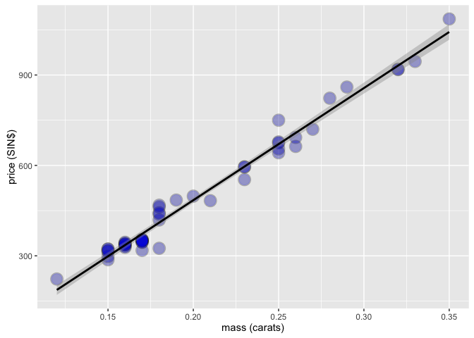

```r
data(diamond)
ggplot(diamond, aes(x=carat, y=price)) +
    xlab('mass (carats)') +
    ylab('price (SIN$)') +
    geom_point(size=6, colour='black', alpha=0.2) +
    geom_point(size=5, colour='blue', alpha=0.2) +
    geom_smooth(method='lm', colour='black')
```

```r
fit <- lm(price ~ carat, diamond)
coef(fit)
```

```
## (Intercept)       carat
##   -259.6259   3721.0249
```

What is says is:

- we estimate a SIN$ 3,721.02 increase in price for every carat in a diamond
- a zero carat diamond should cost SIN$ -259.63 (what doesn’t make any sense)

Let’s deal with a non-sense intercept (second bullet) my subtracting the mean sized diamond from carat size:

```r
fit2 <- lm(price ~ I(carat - mean(carat)), data=diamond) # adjustments have to be surrounded by I() function
coef(fit2)
```

```
##            (Intercept) I(carat - mean(carat))
##               500.0833              3721.0249
```

The slope hasn’t changed, but the intercept makes more sense: SIN$ 500.08 is the expected price to be paid for an average size diamond.

We can make the model better, the slope is a factor of a large amount of money - we can scale volume by 10:

```r
fit3 <- lm(price ~ I(carat*10 - mean(carat*10)), data=diamond) # adjustments have to be surrounded by I() function
coef(fit3)
```

```
##                      (Intercept) I(carat * 10 - mean(carat * 10))
##                         500.0833                         372.1025
```

So, each tenth of carat increase will represent a difference in price of SIN$ 372.10

How to predict prices?

Given 3 diamonds and their sizes:

```r
newx <- c(0.16, 0.27,0.34)
```

First way, simple calculation $Y_i = \beta_0 + \beta_1 X_i$:

```r
coef(fit)[1] + coef(fit)[2] * newx
```

```
## [1]  335.7381  745.0508 1005.5225
```

Second way, using `predict`

```r
predict(fit, newdata=data.frame(carat=newx))
```

```
##         1         2         3
##  335.7381  745.0508 1005.5225
```

Both yield the same results.

# Effect of scale conversion in coefficients

What happens if I divide a scale of X by 10?

```r
x <- c(0.61, 0.93, 0.83, 0.35, 0.54, 0.16, 0.91, 0.62, 0.62)
y <- c(0.67, 0.84, 0.6, 0.18, 0.85, 0.47, 1.1, 0.65, 0.36)
summary(lm(y ~ x))$coefficients
```

```
##              Estimate Std. Error   t value   Pr(>|t|)
## (Intercept) 0.1884572  0.2061290 0.9142681 0.39098029
## x           0.7224211  0.3106531 2.3254912 0.05296439
```

```r
summary(lm(y ~ I(x/10)))$coefficients
```

```
##              Estimate Std. Error   t value   Pr(>|t|)
## (Intercept) 0.1884572   0.206129 0.9142681 0.39098029
## I(x/10)     7.2242108   3.106531 2.3254912 0.05296439
```

Gets multiplied by 10.

What happens if I add a constant K to the regressor?

```r
summary(lm(y ~ I(x + 3)))$coefficients
```

```
##               Estimate Std. Error   t value   Pr(>|t|)
## (Intercept) -1.9788061  1.1266738 -1.756326 0.12245739
## I(x + 3)     0.7224211  0.3106531  2.325491 0.05296439
```

The intercept changed, the relationship:

```r
0.1884572 - 3*0.722421
```

```
## [1] -1.978806
```

The new intercept would be $\hat \beta_0 = \beta_0 - K\beta_1$

Another example using `mtcars`. How should a regressor associated to half of weight be interpreted?

```r
data(mtcars)
summary(lm(mpg ~ wt + factor(cyl), data=mtcars))$coef
```

```
##               Estimate Std. Error   t value     Pr(>|t|)
## (Intercept)  33.990794  1.8877934 18.005569 6.257246e-17
## wt           -3.205613  0.7538957 -4.252065 2.130435e-04
## factor(cyl)6 -4.255582  1.3860728 -3.070244 4.717834e-03
## factor(cyl)8 -6.070860  1.6522878 -3.674214 9.991893e-04
```

```r
summary(lm(mpg ~ I(wt * 0.5) + factor(cyl), data = mtcars))$coef
```

```
##               Estimate Std. Error   t value     Pr(>|t|)
## (Intercept)  33.990794   1.887793 18.005569 6.257246e-17
## I(wt * 0.5)  -6.411227   1.507791 -4.252065 2.130435e-04
## factor(cyl)6 -4.255582   1.386073 -3.070244 4.717834e-03
## factor(cyl)8 -6.070860   1.652288 -3.674214 9.991893e-04
```

# Residuals

## Residuals Properties

Calculating residuals of price and carat correlation data and checking some of the residuals properties:

```r
data(diamond)
y <- diamond$price
x <- diamond$carat
fit <- lm(y ~ x)
e <- resid(fit)
yhat <- predict(fit)
```

Checking residuals, $e_i = Y_i - \hat Y_i$ so $e_i - (Y_i - \hat Y_i) = 0$

```r
max(abs(e - (y - yhat)))
```

```
## [1] 9.485746e-13
```

Almost zero, what should be the same as

```r
max(abs(e - (y - coef(fit)[1] - coef(fit)[2] * x)))
```

```
## [1] 9.485746e-13
```

Expected value of residuals is zero, $E[e_i] = 0$

```r
mean(e)
```

```
## [1] -3.885781e-16
```

Sum of residuals is zero, $\sum{i=1}_n e_i = 0$ if intercept is included:

```r
sum(e)
```

```
## [1] -1.865175e-14
```

Sum of regressor times residuals is zero, $\sum{i=1}_n e_i x_i = 0$ if regressor is included:

```r
sum(e * x)
```

```
## [1] 6.959711e-15
```

## Visual Patterns of Residual Plots

Plotting prices, mass, regression and a red line for residuals:

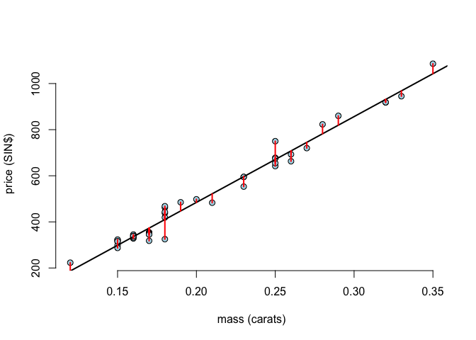

```r
n <- length(y)
plot(x, y, xlab='mass (carats)', ylab='price (SIN$)',
     bg='lightblue',
     col='black', cex=1.1, pch=21, frame=FALSE)
abline(fit, lwd=2)
for (i in 1:n)
    lines(c(x[i], x[i]), c(y[i], yhat[i]), col='red', lwd=2)
```

This is not the best way to represent residuals (check the amount of unused space above and below the regression line). Instead, let’s plot regressors versus residuals:

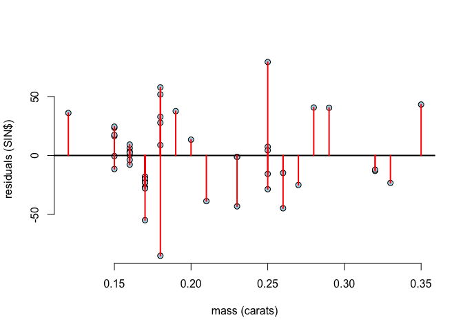

```r
plot(x, e, xlab='mass (carats)', ylab='residuals (SIN$)',
     bg='lightblue',
     col='black', cex=1.1, pch=21, frame=FALSE)
abline(h=0, lwd=2)
for (i in 1:n)
    lines(c(x[i], x[i]), c(e[i], 0), col='red', lwd=2)
```

A few things a residual versus regressor plot should show:

- you should see no patterns of disposition, residuals should spread nicely and without any shape above and below the intercept
- since the intercept is included, red lines should add to ~ zero (positive above the intercept, negative below the intercept)

Now a few example of patological patterns a residual plot should help highlight

```r
x <- runif(100, -3, 3)
y <- x + sin(x) + rnorm(100, sd=.2)
```

Basically a uniform distribution on x, and y a senoid oscilation with a bit of random normal noise over it, a regression line defined by `geom_smooth`:

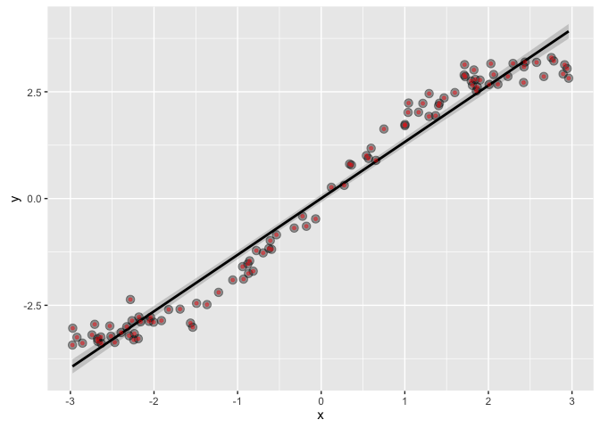

```r
ggplot(data.frame(x=x, y=y), aes(x=x,y=y)) +
    geom_smooth(method='lm', colour='black') +
    geom_point(size=3, colour='black', alpha=0.4) +
    geom_point(size=1, colour='red', alpha=0.4)
```

It is not apparent that some pattern is hidden in the data. Let’s take a look at the residual plot:

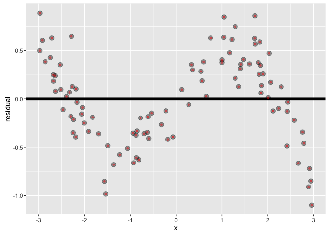

```r
e <- resid(lm(y ~ x))
ggplot(data.frame(x=x, y=e), aes(x=x,y=y)) +
    xlab("x") + ylab("residual") +
    geom_hline(yintercept=0, size=2) +
    geom_point(size=3, colour='black', alpha=0.4) +
    geom_point(size=1, colour='red', alpha=0.4)
```

Now it is apparent that residuals oscilate over and below the reference line of zero.

Another example:

```r
x <- runif(100, 0, 6)
y <- x + rnorm(100, mean=0, sd=.001 * x)
```

X and Y are generated on some pre-determined pattern. X is 100 uniform numbers, Y is X plus 100 random normal numbers - and here is the catch, SD is variable in relation to X - there’s the hidden pattern.

A X over Y plot however shows nothing:

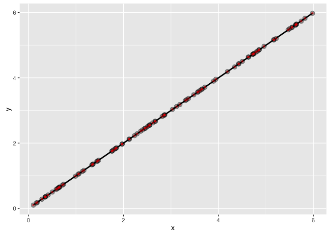

```r
ggplot(data.frame(x=x, y=y), aes(x=x,y=y)) +
    geom_smooth(method='lm', colour='black') +
    geom_point(size=3, colour='black', alpha=0.4) +
    geom_point(size=1, colour='red', alpha=0.4)
```

Shows nothing. Appears as if X and Y fall exactly on top of the identity line. Let’s take a look at the residual plot:

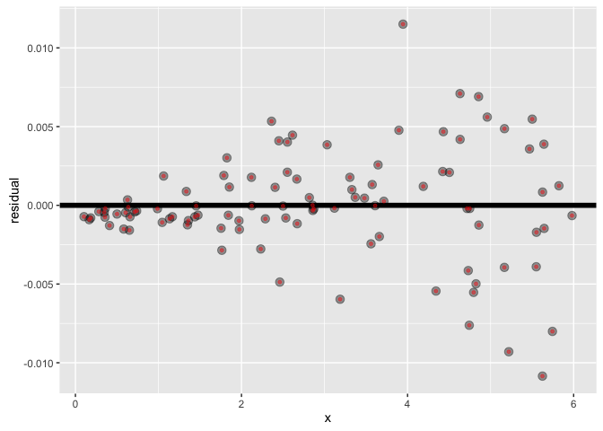

```r
e <- resid(lm(y ~ x))
ggplot(data.frame(x=x, y=e), aes(x=x,y=y)) +
    xlab("x") + ylab("residual") +
    geom_hline(yintercept=0, size=2) +
    geom_point(size=3, colour='black', alpha=0.4) +
    geom_point(size=1, colour='red', alpha=0.4)
```

Shows that residuals spread as the regressor grows to higher values. There is a name for that, heteroscedasticity.

Heteroscedasticity is a hard word to pronounce, but it doesn’t need to be a difficult concept to understand. Put simply, heteroscedasticity (also spelled heteroskedasticity) refers to the circumstance in which the variability of a variable is unequal across the range of values of a second variable that predicts it.

Residual plots are a good tool to diagnose heteroscedasticity.

## Explaining Residuals

Back to our diamond analysis:

```r
diamond$e <- resid(lm(price ~ carat, data=diamond))
head(diamond)
```

```
##   carat price          e
## 1  0.17   355 -17.948318
## 2  0.16   328  -7.738069
## 3  0.17   350 -22.948318
## 4  0.18   325 -85.158566
## 5  0.25   642 -28.630306
## 6  0.16   342   6.261931
```

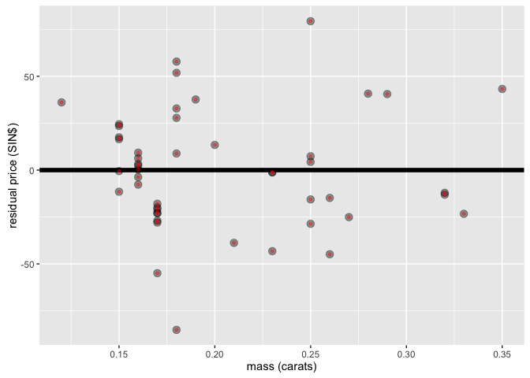

```r
ggplot(diamond, aes(x=carat,y=e)) +
    xlab('mass (carats)') +
    ylab('residual price (SIN$)') +
    geom_hline(yintercept=0, size=2) +
    geom_point(size=3, colour='black', alpha=0.4) +
    geom_point(size=1, colour='red', alpha=0.4)
```

No patterns, but variance - where is this variance related to:

```r
e <- c(resid(lm(price ~ 1, data=diamond)),
       resid(lm(price ~ carat, data=diamond)))
fit <- factor(c(rep('intercept', nrow(diamond)),
                rep('intercept, slope', nrow(diamond))))
```

Residuals are given by $e$, in two vectors:

- first residual vector, just a fitted intercept on 1, so they are just variations around an average price

```r
lm(price ~ 1, data=diamond)
```

```
##
## Call:
## lm(formula = price ~ 1, data = diamond)
##
## Coefficients:
## (Intercept)
##       500.1
```

```r
mean(diamond$price)
```

```
## [1] 500.0833
```

- second residual vector, we add carat as a predictor variable, are variations around a regression line of price ~ carat.

```r
lm(price ~ carat, data=diamond)
```

```
##
## Call:
## lm(formula = price ~ carat, data = diamond)
##
## Coefficients:
## (Intercept)        carat
##      -259.6       3721.0
```

The labelling for the plot is given by factor $fit$.

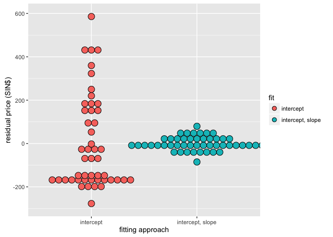

```r
ggplot(data.frame(e=e, fit=fit), aes(x=fit, y=e, fill=fit)) +
    geom_dotplot(binaxis='y', stackdir='center', binwidth=30) +
    xlab('fitting approach') +
    ylab('residual price (SIN$)')
```

On the left side (red), we see the variation of prices around the average diamond prices.

On the right side (blue) we see the variation of prices around the regression line.

## Residual Variance

You can extract the standard variation of a fit using `$sigma`:

```r
fit <- lm(diamond$price ~ diamond$carat)
summary(fit)$sigma
```

```
## [1] 31.84052
```

Residual variance (variance of residuals) should also follow $\hat \sigma^2 = \dfrac{1}{(n - 2)} \sum_{i=1}^n e_i^2$, what when calculated:

```r
n <- length(diamond$price)
sqrt(sum(resid(fit)^2) / (n - 2))
```

```
## [1] 31.84052
```

Gives the exact same results.

This R function should give the exact same result:

```r
sqrt(deviance(fit)/(n-2))
```

```
## [1] 31.84052
```

## Comparing models with different combination of slope and intercept

```r
data(mtcars)
x <- mtcars$wt
y <- mtcars$mpg
```

Slope and intercept:

```r
sifit <- lm(y ~ x)
```

Only intercept

```r
ifit <- lm(y ~ 1)
```

Only slope

```r
sfit <- lm(y ~ x - 1)
```

What is the ratio of the error variability when comparing intercept only to intercept and slope, $\frac {intercept and slope}{intercept}$?

```r
sum(sifit$residuals^2)/sum(ifit$residuals^2)
```

```
## [1] 0.2471672
```

## R Squared

```r
# mean of all Y
mu <- mean(galton$child)
# Centering data means subtracting the mean from each data point.
# Sum of the squares of the centered children's heights gives the total variation
sTot <- sum((galton$child - mu)^2)
fit <- lm(galton$child ~ galton$parent)
# deviance calculates the sum of the squares of the residuals.
# These are the distances between the children's heights and the regression line.
sRes <- deviance(fit)
r2 <- 1 - (sRes/sTot)
r2
```

```
## [1] 0.2104629
```

What is the same as

```r
summary(fit)$r.squared
```

```
## [1] 0.2104629
```

And since $R^2 = cor(x,y)^2$:

```r
cor(galton$child, galton$parent)^2
```

```
## [1] 0.2104629
```

```r
data("anscombe"); example("anscombe")
```

```
##
## anscmb> require(stats); require(graphics)
##
## anscmb> summary(anscombe)
##        x1             x2             x3             x4
##  Min.   : 4.0   Min.   : 4.0   Min.   : 4.0   Min.   : 8
##  1st Qu.: 6.5   1st Qu.: 6.5   1st Qu.: 6.5   1st Qu.: 8
##  Median : 9.0   Median : 9.0   Median : 9.0   Median : 8
##  Mean   : 9.0   Mean   : 9.0   Mean   : 9.0   Mean   : 9
##  3rd Qu.:11.5   3rd Qu.:11.5   3rd Qu.:11.5   3rd Qu.: 8
##  Max.   :14.0   Max.   :14.0   Max.   :14.0   Max.   :19
##        y1               y2              y3              y4
##  Min.   : 4.260   Min.   :3.100   Min.   : 5.39   Min.   : 5.250
##  1st Qu.: 6.315   1st Qu.:6.695   1st Qu.: 6.25   1st Qu.: 6.170
##  Median : 7.580   Median :8.140   Median : 7.11   Median : 7.040
##  Mean   : 7.501   Mean   :7.501   Mean   : 7.50   Mean   : 7.501
##  3rd Qu.: 8.570   3rd Qu.:8.950   3rd Qu.: 7.98   3rd Qu.: 8.190
##  Max.   :10.840   Max.   :9.260   Max.   :12.74   Max.   :12.500
##
## anscmb> ##-- now some "magic" to do the 4 regressions in a loop:
## anscmb> ff <- y ~ x
##
## anscmb> mods <- setNames(as.list(1:4), paste0("lm", 1:4))
##
## anscmb> for(i in 1:4) {
## anscmb+   ff[2:3] <- lapply(paste0(c("y","x"), i), as.name)
## anscmb+   ## or   ff[[2]] <- as.name(paste0("y", i))
## anscmb+   ##      ff[[3]] <- as.name(paste0("x", i))
## anscmb+   mods[[i]] <- lmi <- lm(ff, data = anscombe)
## anscmb+   print(anova(lmi))
## anscmb+ }
## Analysis of Variance Table
##
## Response: y1
##           Df Sum Sq Mean Sq F value  Pr(>F)
## x1         1 27.510 27.5100   17.99 0.00217 **
## Residuals  9 13.763  1.5292
## ---
## Signif. codes:  0 '***' 0.001 '**' 0.01 '*' 0.05 '.' 0.1 ' ' 1
## Analysis of Variance Table
```

[output cut: 46 more lines]

```
## $lm4
##              Estimate Std. Error  t value    Pr(>|t|)
## (Intercept) 3.0017273  1.1239211 2.670763 0.025590425
## x4          0.4999091  0.1178189 4.243028 0.002164602
##
##
## anscmb> ## Now, do what you should have done in the first place: PLOTS
## anscmb> op <- par(mfrow = c(2, 2), mar = 0.1+c(4,4,1,1), oma =  c(0, 0, 2, 0))
##
## anscmb> for(i in 1:4) {
## anscmb+   ff[2:3] <- lapply(paste0(c("y","x"), i), as.name)
## anscmb+   plot(ff, data = anscombe, col = "red", pch = 21, bg = "orange", cex = 1.2,
## anscmb+        xlim = c(3, 19), ylim = c(3, 13))
## anscmb+   abline(mods[[i]], col = "blue")
## anscmb+ }
```

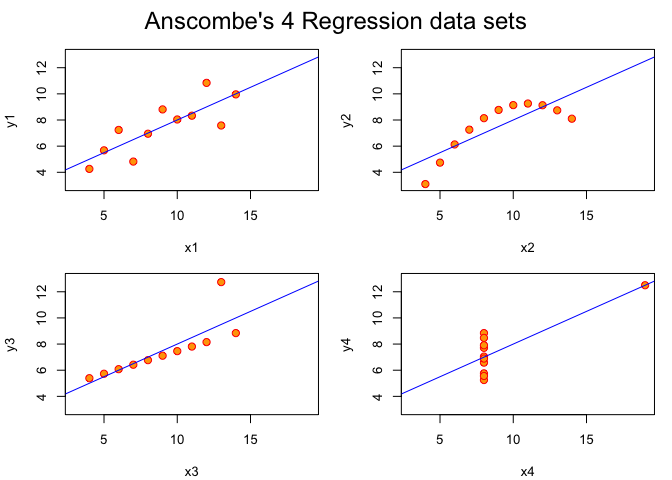

```
##
## anscmb> mtext("Anscombe's 4 Regression data sets", outer = TRUE, cex = 1.5)
##
## anscmb> par(op)
```

On all these examples we have a similar $R_2$, but the disposition of the data shows information is missing.

# Inference in Regression

Let’s get back to the diamond data using mass to regress the price of diamonds:

```r
library(UsingR); data(diamond)
y <- diamond$price
x <- diamond$carat
n <- length(y)
```

## Coefficients Calculation

The hard way of doing it:

```r
beta1 <- cor(y, x) * sd(y)/sd(x)
beta0 <- mean(y) - beta1 * mean(x)
e <- y - beta0 - beta1 * x # residuals
sigma <- sqrt(sum(e^2) / (n-2)) # estimate of std deviation
ssx <- sum((x - mean(x))^2) # sums of squares of x's
seBeta0 <- (1 / n + mean(x)^2 / ssx) ^.5 * sigma
seBeta1 <- sigma / sqrt(ssx)
tBeta0 <- beta0 / seBeta0
tBeta1 <- beta1 / seBeta1
pBeta0 <- 2 * pt(abs(tBeta0), df=n-2, lower.tail=FALSE)
pBeta1 <- 2 * pt(abs(tBeta1), df=n-2, lower.tail=FALSE)
coefTable <- rbind(c(beta0, seBeta0, tBeta0, pBeta0),
                   c(beta1, seBeta1, tBeta1, pBeta1))
colnames(coefTable) <- c('Estimate', 'Std. Error', 't value', 'P(>|t|)')
rownames(coefTable) <- c('(Intercept)', 'x')
coefTable
```

```
##              Estimate Std. Error   t value      P(>|t|)
## (Intercept) -259.6259   17.31886 -14.99094 2.523271e-19
## x           3721.0249   81.78588  45.49715 6.751260e-40
```

The easy way to come up with the exact same values:

```r
fit <- lm(y ~ x)
summary(fit)$coefficients
```

```
##              Estimate Std. Error   t value     Pr(>|t|)
## (Intercept) -259.6259   17.31886 -14.99094 2.523271e-19
## x           3721.0249   81.78588  45.49715 6.751260e-40
```

Both steps produce the exact same results.

## Hypothesis Testing

```r
x <- c(0.61, 0.93, 0.83, 0.35, 0.54, 0.16, 0.91, 0.62, 0.62)
y <- c(0.67, 0.84, 0.6, 0.18, 0.85, 0.47, 1.1, 0.65, 0.36)
```

What is the p-value for the 2 sided hypothesis test if $\beta_1$ from a linear regression is 0 or not?

```r
fit <- lm(y ~ x)
summary(fit)$coef
```

```
##              Estimate Std. Error   t value   Pr(>|t|)
## (Intercept) 0.1884572  0.2061290 0.9142681 0.39098029
## x           0.7224211  0.3106531 2.3254912 0.05296439
```

The first row is $\beta_0$, second row is $\beta_1$ - so result is ~ 0.052964.

## Confidence Intervals

Now, if we want to produce confidence intervals

```r
library(UsingR); data(diamond)
y <- diamond$price
x <- diamond$carat
n <- length(y)
fit <- lm(y ~ x)
sumCoef <- summary(fit)$coefficients
```

95% confidence interval for $\beta_0$ (intercept):

```r
beta0Estimate <- sumCoef[1,1]
beta0StdError <- sumCoef[1,2]
beta0Estimate + c(-1,1) * qt(.975, df=fit$df) * beta0StdError
```

```
## [1] -294.4870 -224.7649
```

95% confidence interval for $\beta_1$ (slope):

```r
beta1Estimate <- sumCoef[2,1]
beta1StdError <- sumCoef[2,2]
beta1Estimate + c(-1,1) * qt(.975, df=fit$df) * beta1StdError
```

```
## [1] 3556.398 3885.651
```

What this is basically stating is, with a 95% confidence, that a increase of 1 carat in mass will cause a diamond price to increase anything from SIN$ 3556.39 to SIN$ 3885.65

On cars, the mtcars data set, what is a 95% *confidence interval* for the expected mpg at the average weight?

```r
data(mtcars)
x <- mtcars$wt
y <- mtcars$mpg
fit <- lm(y ~ x)
predict(fit, data.frame(x=mean(x)), interval='confidence', level=0.95)
```

```
##        fit      lwr      upr
## 1 20.09062 18.99098 21.19027
```

A new 3,000 pounds will be on sale soon. What is a 95% *prediction interval* of it’s mpg consumption?

```r
predict(fit, data.frame(x=3.0), interval='prediction', level=0.95)
```

```
##        fit      lwr      upr
## 1 21.25171 14.92987 27.57355
```

What is a 95% confidence interval for the *expected change* in mpg per 2,000 lbs increase in weight?

```r
fit <- lm(y ~ I(x/2)) # x/2 is x/2000 pounds since x is in 1000 pounds
sumCoef <- summary(fit)$coefficients
beta1Estimate <- sumCoef[2,1]
beta1StdError <- sumCoef[2,2]
beta1CI95 <- beta1Estimate + c(-1,1) * qt(.975, df=fit$df) * beta1StdError
beta1CI95
```

```
## [1] -12.97262  -8.40527
```

## Prediction

```r
library(UsingR); data(diamond)
y <- diamond$price
x <- diamond$carat
n <- length(y)
fit <- lm(y ~ x)
newx <- data.frame(x=seq(min(x), max(x), length=100))
p1 <- data.frame(predict(fit, newdata=newx, interval=('confidence')))
p2 <- data.frame(predict(fit, newdata=newx, interval=('prediction')))
p1$interval <- 'confidence'
p2$interval <- 'prediction'
p1$x <- newx$x
p2$x <- newx$x
dat <- rbind(p1, p2)
names(dat)[1] <- 'y'
```

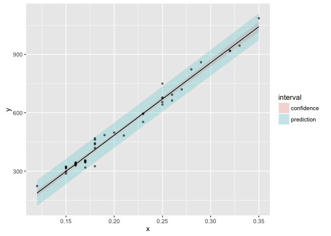

```r
ggplot(dat, aes(x=x, y=y)) +
    geom_ribbon(aes(ymin=lwr, ymax=upr, fill=interval), alpha=0.2) +
    geom_line() +
    geom_point(data=data.frame(x=x,y=y), aes(x=x,y=y), size=1, alpha=0.5)
```

# Multivariate Regression

## Experiment

```r
n <- 100
# predictors
x1 <- rnorm(n); x2 <- rnorm(n); x3 <- rnorm(n)
# outcome
y <- 1 + x1 + x2 + x3 + rnorm(n, sd=.1)
```

Calculating residuals for $Y$ and $X_1$:

```r
ey <- resid(lm(y ~ x2 + x3))
ex1 <- resid(lm(x1 ~ x2 + x3))
```

Calculating $\hat \beta_1$:

```r
sum(ey * ex1) / sum(ex1 ^ 2)
```

```
## [1] 1.006773
```

Same as:

```r
coef(lm(ey ~ ex1 - 1))
```

```
##      ex1
## 1.006773
```

And should be the same if you add all regressors, looking under column x1:

```r
coef(lm(y ~ x1 + x2 + x3))
```

```
## (Intercept)          x1          x2          x3
##   0.9962623   1.0067733   0.9900412   0.9978590
```

## Sample Analysys: Swiss Population Late 1800

We will start by a pairs plot:

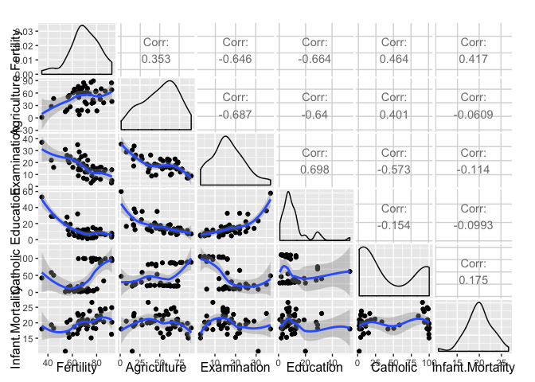

```r
data(swiss)
my_fn <- function(data, mapping, method="loess", ...){
      p <- ggplot(data = data, mapping = mapping) +
      geom_point() +
      geom_smooth(method=method, ...)
      p
    }
ggpairs(swiss, lower=list(continuous=my_fn))
```

Regress fertility as an outcome of all variables

```r
summary(lm(Fertility ~ ., data=swiss))$coefficients
```

```
##                    Estimate  Std. Error   t value     Pr(>|t|)
## (Intercept)      66.9151817 10.70603759  6.250229 1.906051e-07
## Agriculture      -0.1721140  0.07030392 -2.448142 1.872715e-02
## Examination      -0.2580082  0.25387820 -1.016268 3.154617e-01
## Education        -0.8709401  0.18302860 -4.758492 2.430605e-05
## Catholic          0.1041153  0.03525785  2.952969 5.190079e-03
## Infant.Mortality  1.0770481  0.38171965  2.821568 7.335715e-03
```

Let’s go over a few of these numbers one by one:

Agriculture Estimate -0.1721140 : we expect a .17 decrease on standardized fertility rates for every 1% of males involved in agriculture, holding the remanining variables constant.

Agriculture Std.Error 0.07030392: tells us how precise this estimate is. If we were to test $H_0 : \beta_{Agri} = 0$ versus $H_a : \beta{Agri} <> 0$ - we test against $\frac {estimate - \beta_{Agri}}{std error}$

Agriculture t value -2.448142: using $\beta_{Agri} = 0$ estimate divided by std error, -0.1721140/0.07030392

Agriculture Pr(>|t|) 1.872715e-02: probability of getting a t-statistic as extreme as t value

```r
summary(lm(Fertility ~ Agriculture, data=swiss))$coefficients
```

```
##               Estimate Std. Error   t value     Pr(>|t|)
## (Intercept) 60.3043752 4.25125562 14.185074 3.216304e-18
## Agriculture  0.1942017 0.07671176  2.531577 1.491720e-02
```

Coeficients are reversed when we remove all the other regressor variables. A few findings:

- The coeficient sign in Agriculture reverses itself with the inclusion of Examination and Education.
- Agricultural work is negatively correlated to educational attainment (-0.6395), while education and examination (correlation of 0.6984) are measuring equivalent things
- A causality claim between Agriculture and Fertility will be easily negated, all you have to do is to add more variables and the causality would be reversed or gone away.

What happens if you include an replicated/irrelevant regressor?

```r
z <- swiss$Agriculture + swiss$Education
lm(Fertility ~ . + z, data=swiss)
```

```
##
## Call:
## lm(formula = Fertility ~ . + z, data = swiss)
##
## Coefficients:
##      (Intercept)       Agriculture       Examination         Education
##          66.9152           -0.1721           -0.2580           -0.8709
##         Catholic  Infant.Mortality                 z
##           0.1041            1.0770                NA
```

R responds back with a `NA` for z, meaning it is irrelevant to the model already in place.

## Factor Variables for Analysis

```r
data("InsectSprays")
head(InsectSprays)
```

```
##   count spray
## 1    10     A
## 2     7     A
## 3    20     A
## 4    14     A
## 5    14     A
## 6    12     A
```

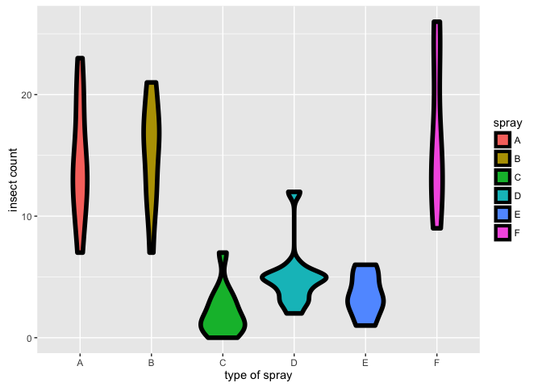

```r
ggplot(data=InsectSprays, aes(y=count, x=spray, fill=spray)) +
    geom_violin(colour='black', size=2) +
    xlab('type of spray') + ylab('insect count')
```

Let’s fit our model, using predictor as spray and count as the outcome

```r
summary(lm(count ~ spray, data=InsectSprays))$coef
```

```
##                Estimate Std. Error    t value     Pr(>|t|)
## (Intercept)  14.5000000   1.132156 12.8074279 1.470512e-19
## sprayB        0.8333333   1.601110  0.5204724 6.044761e-01
## sprayC      -12.4166667   1.601110 -7.7550382 7.266893e-11
## sprayD       -9.5833333   1.601110 -5.9854322 9.816910e-08
## sprayE      -11.0000000   1.601110 -6.8702352 2.753922e-09
## sprayF        2.1666667   1.601110  1.3532281 1.805998e-01
```

You can see that SprayA is missing - that’s becasue it hs been picked as the reference predictor.

A second example: using `mtcars`, fit a model with mpg as the outcome that includes number of cylinders as a factor variable and weight (wt) as confounder. Find the adjusted estimate for the expected change in mpg comparing 8 cylinders to 4.

```r
mtcars$cylf <- factor(mtcars$cyl)
fit <- lm(mpg ~ cylf + wt, mtcars)
summary(fit)$coef
```

```
##              Estimate Std. Error   t value     Pr(>|t|)
## (Intercept) 33.990794  1.8877934 18.005569 6.257246e-17
## cylf6       -4.255582  1.3860728 -3.070244 4.717834e-03
## cylf8       -6.070860  1.6522878 -3.674214 9.991893e-04
## wt          -3.205613  0.7538957 -4.252065 2.130435e-04
```

The baseline in `(Intercept)` is the regressor factor 4 cylinders. Holding weight constant, the estimate for `cylf8` is relative to 4 cylinders, so the expected change is given by estimate of cylf8L: **-6.070860**

Now, how do estimates of mpg as outcome and cylinders as factor, holding weight constant and without weight? In other words, how does mpg vary in relation to cylinders, adjusted and not adjusted for weight?

```r
fitNotAdjusted <- lm(mpg ~ cylf, mtcars)
summary(fitNotAdjusted)$coef
```

```
##               Estimate Std. Error   t value     Pr(>|t|)
## (Intercept)  26.663636  0.9718008 27.437347 2.688358e-22
## cylf6        -6.920779  1.5583482 -4.441099 1.194696e-04
## cylf8       -11.563636  1.2986235 -8.904534 8.568209e-10
```

If we compare coeficients of `fit` to `fitNotAdjusted` we are basically comparing the mpg rate when we keep weight constant (fit) to when we removed weight (fitNotAdjusted). The difference in mpg from 8 to 4 cylinders changed from **-6.070860** to **-11.563636** from coefficients on `fit` to `fitNotAdjusted`.

So, holding weight constant has less of an impact in mpg consumption than removing weight altogether.

Another test: would adding a regressor of an interaction between number of cylinders (as a factor) and weight have any significant effect in the prediction of the outcome mpg?

Let’s first generate the new fit, adding a regressor of the interaction of wt and cylf (remember, interactions are recorded using the `*` operator):

```r
fitInteraction <- lm(mpg ~ wt + cylf + wt*cylf, mtcars)
summary(fitInteraction)$coef
```

```
##               Estimate Std. Error    t value     Pr(>|t|)
## (Intercept)  39.571196   3.193940 12.3894599 2.058359e-12
## wt           -5.647025   1.359498 -4.1537586 3.127578e-04
## cylf6       -11.162351   9.355346 -1.1931522 2.435843e-01
## cylf8       -15.703167   4.839464 -3.2448150 3.223216e-03
## wt:cylf6      2.866919   3.117330  0.9196716 3.661987e-01
## wt:cylf8      3.454587   1.627261  2.1229458 4.344037e-02
```

What’s the p-value for the likelihood ratio test comparing the two models, and should we reject the hypothesis using 0.05 as a type I error rate significance benchmark?

```r
anova(fit, fitInteraction)
```

```
## Analysis of Variance Table
##
## Model 1: mpg ~ cylf + wt
## Model 2: mpg ~ wt + cylf + wt * cylf
##   Res.Df    RSS Df Sum of Sq      F Pr(>F)
## 1     28 183.06
## 2     26 155.89  2     27.17 2.2658 0.1239
```

Since the p-value is greater that 0.05 (our $\alpha$ for the benchmark), it would fail to reject the hypothesis (i.e. the interaction terms are not necessary)

### Estimates

- The estimate of 14.5 is the mean of sprayA (see the violin plot).
- Other estimates are the difference in means between sprayX and the reference predictor sprayA.
- The probability column is checking the probability of a sprayX being different from the reference sprayA.
- If you want to find a mean of a specific predictor you will have to add that to the reference predictor sprayA located in the intercept. For example for mean for sprayE:

```r
14.5000000 + -11.0000000
```

```
## [1] 3.5
```

- If you have to compare means of other predictors, you will have to subtract one the other, for example - to compare means of sprayC and sprayF, the comparison would be sprayF - sprayC:

```r
2.1666667 -12.4166667
```

```
## [1] -10.25
```

Note that this does not provide an error estimate.

### Fitting a curve by hand

You can fit the curve above

```r
summary(lm(count ~ spray, data=InsectSprays))$coef
```

```
##                Estimate Std. Error    t value     Pr(>|t|)
## (Intercept)  14.5000000   1.132156 12.8074279 1.470512e-19
## sprayB        0.8333333   1.601110  0.5204724 6.044761e-01
## sprayC      -12.4166667   1.601110 -7.7550382 7.266893e-11
## sprayD       -9.5833333   1.601110 -5.9854322 9.816910e-08
## sprayE      -11.0000000   1.601110 -6.8702352 2.753922e-09
## sprayF        2.1666667   1.601110  1.3532281 1.805998e-01
```

With an equivalent, done by hand, set of regressors using the following pattern:

```r
summary(lm(count ~
               I(1 * (spray == 'B')) +
               I(1 * (spray == 'C')) +
               I(1 * (spray == 'D')) +
               I(1 * (spray == 'E')) +
               I(1 * (spray == 'F')),
           data=InsectSprays))$coef
```

```
##                          Estimate Std. Error    t value     Pr(>|t|)
## (Intercept)            14.5000000   1.132156 12.8074279 1.470512e-19
## I(1 * (spray == "B"))   0.8333333   1.601110  0.5204724 6.044761e-01
## I(1 * (spray == "C")) -12.4166667   1.601110 -7.7550382 7.266893e-11
## I(1 * (spray == "D"))  -9.5833333   1.601110 -5.9854322 9.816910e-08
## I(1 * (spray == "E")) -11.0000000   1.601110 -6.8702352 2.753922e-09
## I(1 * (spray == "F"))   2.1666667   1.601110  1.3532281 1.805998e-01
```

You add `1 *` to force the type from boolean to numeric. When you leave spray ‘A’ out, you force it to be the reference predictor.

What if I add spray A as a predictor to the fitting?

```r
summary(lm(count ~
               I(1 * (spray == 'B')) +
               I(1 * (spray == 'C')) +
               I(1 * (spray == 'D')) +
               I(1 * (spray == 'E')) +
               I(1 * (spray == 'F')) +
               I(1 * (spray == 'A')),
           data=InsectSprays))
```

```
##
## Call:
## lm(formula = count ~ I(1 * (spray == "B")) + I(1 * (spray ==
##     "C")) + I(1 * (spray == "D")) + I(1 * (spray == "E")) + I(1 *
##     (spray == "F")) + I(1 * (spray == "A")), data = InsectSprays)
##
## Residuals:
##    Min     1Q Median     3Q    Max
## -8.333 -1.958 -0.500  1.667  9.333
##
## Coefficients: (1 not defined because of singularities)
##                       Estimate Std. Error t value Pr(>|t|)
## (Intercept)            14.5000     1.1322  12.807  < 2e-16 ***
## I(1 * (spray == "B"))   0.8333     1.6011   0.520    0.604
## I(1 * (spray == "C")) -12.4167     1.6011  -7.755 7.27e-11 ***
## I(1 * (spray == "D"))  -9.5833     1.6011  -5.985 9.82e-08 ***
## I(1 * (spray == "E")) -11.0000     1.6011  -6.870 2.75e-09 ***
## I(1 * (spray == "F"))   2.1667     1.6011   1.353    0.181
## I(1 * (spray == "A"))       NA         NA      NA       NA
## ---
## Signif. codes:  0 '***' 0.001 '**' 0.01 '*' 0.05 '.' 0.1 ' ' 1
##
## Residual standard error: 3.922 on 66 degrees of freedom
## Multiple R-squared:  0.7244, Adjusted R-squared:  0.7036
## F-statistic:  34.7 on 5 and 66 DF,  p-value: < 2.2e-16
```

The coeficients remain the same, but note that R marked spray A as `NA`. In other words, since we already have all the regressors to get to the fitting with sprayA as the reference. adding sprayA again will flagged a new regressor sprayA as irrelevant.

If we remove the intercept however, we will tell R to stop working with a reference. We do that with the pattern `- 1` to indicate removal the intercept ($\beta_0$) regressor:

```r
summary(lm(count ~ spray - 1, data=InsectSprays))$coef
```

```
##         Estimate Std. Error   t value     Pr(>|t|)
## sprayA 14.500000   1.132156 12.807428 1.470512e-19
## sprayB 15.333333   1.132156 13.543487 1.001994e-20
## sprayC  2.083333   1.132156  1.840148 7.024334e-02
## sprayD  4.916667   1.132156  4.342749 4.953047e-05
## sprayE  3.500000   1.132156  3.091448 2.916794e-03
## sprayF 16.666667   1.132156 14.721181 1.573471e-22
```

Now all estimates indicate the mean of that spray on the count, all values are absolute to that specific factor.

The probability column now is checking the probability of a sprayX being different than zero.

### Re-Leveling

We can change the reference predictor by using `relevel`:

```r
spray2 <- relevel(InsectSprays$spray, 'C')
summary(lm(count ~ spray2, data=InsectSprays))$coef
```

```
##              Estimate Std. Error  t value     Pr(>|t|)
## (Intercept)  2.083333   1.132156 1.840148 7.024334e-02
## spray2A     12.416667   1.601110 7.755038 7.266893e-11
## spray2B     13.250000   1.601110 8.275511 8.509776e-12
## spray2D      2.833333   1.601110 1.769606 8.141205e-02
## spray2E      1.416667   1.601110 0.884803 3.794750e-01
## spray2F     14.583333   1.601110 9.108266 2.794343e-13
```

## Bi-Modal Regressor and Interaction Terms

Back to our swiss sensus example:

```r
data(swiss)
head(swiss)
```

```
##              Fertility Agriculture Examination Education Catholic
## Courtelary        80.2        17.0          15        12     9.96
## Delemont          83.1        45.1           6         9    84.84
## Franches-Mnt      92.5        39.7           5         5    93.40
## Moutier           85.8        36.5          12         7    33.77
## Neuveville        76.9        43.5          17        15     5.16
## Porrentruy        76.1        35.3           9         7    90.57
##              Infant.Mortality
## Courtelary               22.2
## Delemont                 22.2
## Franches-Mnt             20.2
## Moutier                  20.3
## Neuveville               20.6
## Porrentruy               26.6
```

Let’s take a look at Catholic:

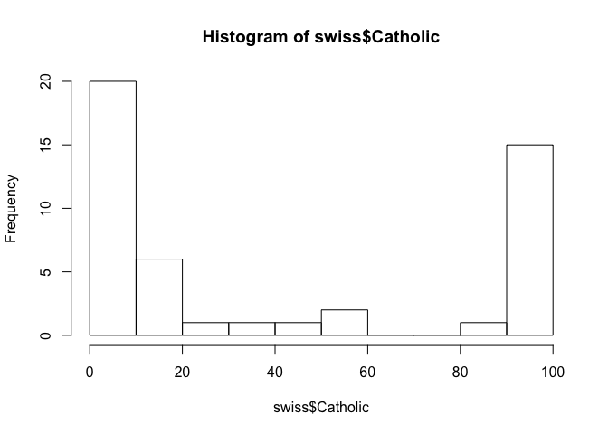

```r
hist(swiss$Catholic)
```

We can see that this data is mostly bi-modal, i.e. indicates if a provice is a majority catholic or non-catholic. We should make this a binary indicator of a catholic majority:

```r
swiss <- mutate(swiss, MajorityCatholic = 1 * (Catholic > 50))
```

And here is how a scatter plot of the data looks like

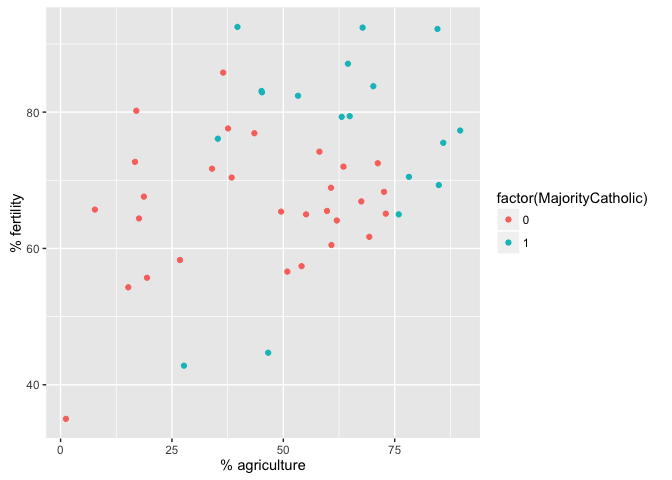

```r
ggplot(swiss, aes(x=Agriculture, y=Fertility)) +
    geom_point(aes(color=factor(MajorityCatholic))) +
    xlab('% agriculture') + ylab('% fertility')
```

Let’s fit a line through the entire population, disregarding the majority binary indicator:

```r
fit <- lm(Fertility ~ Agriculture, data=swiss)
summary(fit)$coef
```

```
##               Estimate Std. Error   t value     Pr(>|t|)
## (Intercept) 60.3043752 4.25125562 14.185074 3.216304e-18
## Agriculture  0.1942017 0.07671176  2.531577 1.491720e-02
```

```r
c(coef(fit)[1], coef(fit)[2])
```

```
## (Intercept) Agriculture
##  60.3043752   0.1942017
```

And adding an `geom_abline` for the regression line.

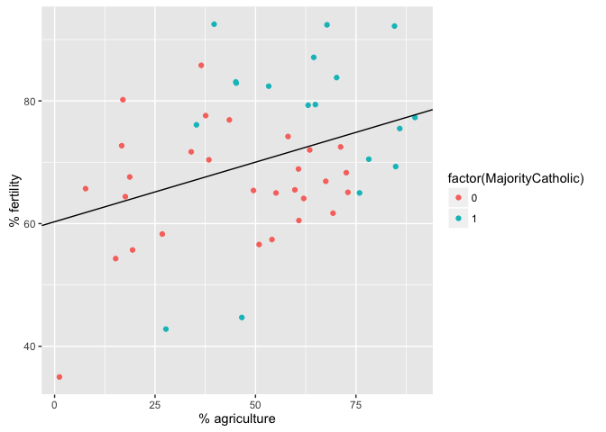

```r
ggplot(swiss, aes(x=Agriculture, y=Fertility)) +
    geom_point(aes(color=factor(MajorityCatholic))) +
    geom_abline(intercept=coef(fit)[1], slope=coef(fit)[2], size=0.5) +
    xlab('% agriculture') + ylab('% fertility')
```

We want to fit a line in each of the populations, let’s try one thing first: adding the factor for the binary predictor:

```r
fit <- lm(Fertility ~ Agriculture + factor(MajorityCatholic), data=swiss)
summary(fit)$coef
```

```
##                             Estimate Std. Error   t value     Pr(>|t|)
## (Intercept)               60.8322366  4.1058630 14.815944 1.032493e-18
## Agriculture                0.1241776  0.0810977  1.531210 1.328763e-01
## factor(MajorityCatholic)1  7.8843292  3.7483622  2.103406 4.118221e-02
```

We care about the following pairs of interceptor/slopes:

```r
c(coef(fit)[1], coef(fit)[2])
```

```
## (Intercept) Agriculture
##  60.8322366   0.1241776
```

```r
c(coef(fit)[1] + coef(fit)[3], coef(fit)[2])
```

```
## (Intercept) Agriculture
##  68.7165659   0.1241776
```

For the second, remember that means have to be added for a reference predictor.

And here are they, in the plot:

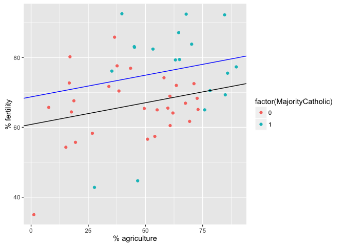

```r
ggplot(swiss, aes(x=Agriculture, y=Fertility)) +
    geom_point(aes(color=factor(MajorityCatholic))) +
    geom_abline(intercept=coef(fit)[1], slope=coef(fit)[2], size=0.5) +
    geom_abline(intercept=coef(fit)[1] + coef(fit)[3], slope=coef(fit)[2], size=0.5, colour='blue') +
    xlab('% agriculture') + ylab('% fertility')
```

Not what we are looking for. Both lines have the same slope.

Let’s fit with a product `*` of factors:

```r
fit <- lm(Fertility ~ Agriculture * factor(MajorityCatholic), data=swiss)
summary(fit)$coef
```

```
##                                          Estimate  Std. Error    t value
## (Intercept)                           62.04993019  4.78915566 12.9563402
## Agriculture                            0.09611572  0.09881204  0.9727127
## factor(MajorityCatholic)1              2.85770359 10.62644275  0.2689238
## Agriculture:factor(MajorityCatholic)1  0.08913512  0.17610660  0.5061430
##                                           Pr(>|t|)
## (Intercept)                           1.919379e-16
## Agriculture                           3.361364e-01
## factor(MajorityCatholic)1             7.892745e-01
## Agriculture:factor(MajorityCatholic)1 6.153416e-01
```

We care about the following pairs of interceptor/slopes:

```r
c(coef(fit)[1], coef(fit)[2])
```

```
## (Intercept) Agriculture
## 62.04993019  0.09611572
```

```r
c(coef(fit)[1] + coef(fit)[3], coef(fit)[2] + coef(fit)[4])
```

```
## (Intercept) Agriculture
##  64.9076338   0.1852508
```

Again, remember that means have to be added for a reference predictor.

And here are they, in the plot:

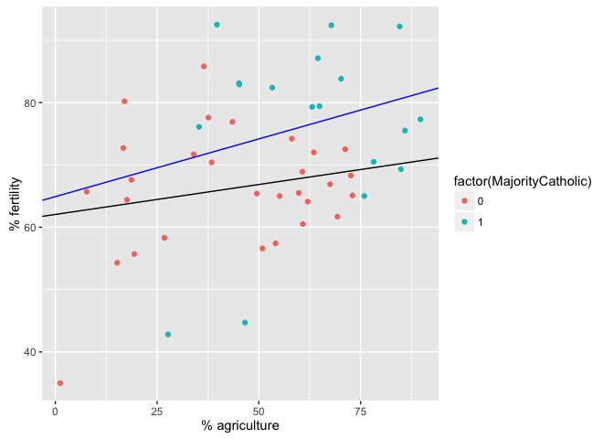

```r
ggplot(swiss, aes(x=Agriculture, y=Fertility)) +
    geom_point(aes(color=factor(MajorityCatholic))) +
    geom_abline(intercept=coef(fit)[1], slope=coef(fit)[2], size=0.5) +
    geom_abline(intercept=coef(fit)[1] + coef(fit)[3],
                slope=coef(fit)[2] + coef(fit)[4], size=0.5, colour='blue') +
    xlab('% agriculture') + ylab('% fertility')
```

Blue line is the fitting for mostly catholic provinces.

And this is what we were looking for.

## Gaussian Elimination

```r
ones <- rep(1, nrow(galton))
```

The default intercept can be excluded by using -1 in the formula. Perform a regression which substitutes our regressor, ones, for the default using lm(child ~ ones + parent -1, galton)

```r
lm(child ~ ones + parent - 1, galton)
```

```
##
## Call:
## lm(formula = child ~ ones + parent - 1, data = galton)
##
## Coefficients:
##    ones   parent
## 23.9415   0.6463
```

The regression in one variable given by lm(child ~ parent, galton) really involves two regressors, the variable, parent, and a regressor of all ones (what in the case before was “Intercept”).

```r
lm(child ~ parent, galton)
```

```
##
## Call:
## lm(formula = child ~ parent, data = galton)
##
## Coefficients:
## (Intercept)       parent
##     23.9415       0.6463
```

The regression line given by lm(child ~ parent, galton) goes through the point x=mean(parent), y=mean(child). If we subtract the mean from each variable, the regression line goes through the origin, x=0, y=0, hence its intercept is zero.

Thus, by subtracting the means, we eliminate one of the two regressors, the constant, leaving just one, parent. The coefficient of the remaining regressor is the slope.

Subtracting the means to eliminate the intercept is a special case of a general technique which is sometimes called *Gaussian Elimination*. As it applies here, the general technique is to pick one regressor and to replace all other variables by the residuals of their regressions against that one.

A residual is the difference between a variable and its predicted value. If, for example, child-mean(child) is a residual, then mean(child) must be its predicted value. But mean(child) is a constant, so the regressor would be a constant (one).

# Adjustment

Adjustment, is the idea of putting regressors into a linear model to investigate the role of a third variable on the relationship between another two. It is often the case that a third variable can distort, or confound, the relationship between two others.

We will look at a few simulations to illustrate the following points: * Modeling multivariate relationships is difficult. * Play around with simulations to see how the inclusion or exclusion of another variable can change analyses. * The results of these analyses deal with the impact of variables on associations. + Ascertaining mechanisms or cause are difficult subjects to be added on top of difficulty in understanding multivariate associations.

## First Simulation

Let’s look at the first simulation.

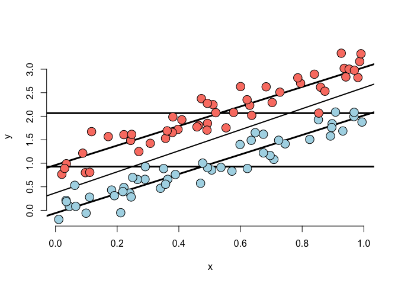

```r
n <- 100; t <- rep(c(0, 1), c(n/2, n/2)); x <- c(runif(n/2), runif(n/2));
beta0 <- 0; beta1 <- 2; tau <- 1; sigma <- .2
y <- beta0 + x * beta1 + t * tau + rnorm(n, sd = sigma)
plot(x, y, type = "n", frame = FALSE)
abline(lm(y ~ x), lwd = 2)
abline(h = mean(y[1 : (n/2)]), lwd = 3)
abline(h = mean(y[(n/2 + 1) : n]), lwd = 3)
fit <- lm(y ~ x + t)
abline(coef(fit)[1], coef(fit)[2], lwd = 3)
abline(coef(fit)[1] + coef(fit)[3], coef(fit)[2], lwd = 3)
points(x[1 : (n/2)], y[1 : (n/2)], pch = 21, col = "black", bg = "lightblue", cex = 2)
points(x[(n/2 + 1) : n], y[(n/2 + 1) : n], pch = 21, col = "black", bg = "salmon", cex = 2)
```

Status is either red or blue, given by the color of the group.

## Second Simulation

On the second simulation:

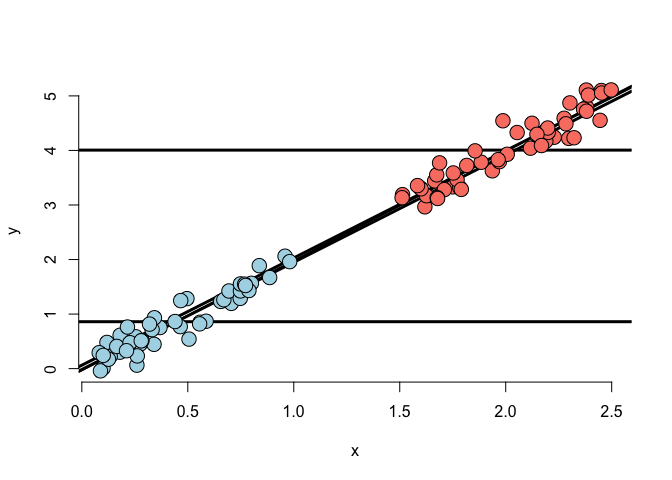

```r
n <- 100; t <- rep(c(0, 1), c(n/2, n/2)); x <- c(runif(n/2), 1.5 + runif(n/2));
beta0 <- 0; beta1 <- 2; tau <- 0; sigma <- .2
y <- beta0 + x * beta1 + t * tau + rnorm(n, sd = sigma)
plot(x, y, type = "n", frame = FALSE)
abline(lm(y ~ x), lwd = 2)
abline(h = mean(y[1 : (n/2)]), lwd = 3)
abline(h = mean(y[(n/2 + 1) : n]), lwd = 3)
fit <- lm(y ~ x + t)
abline(coef(fit)[1], coef(fit)[2], lwd = 3)
abline(coef(fit)[1] + coef(fit)[3], coef(fit)[2], lwd = 3)
points(x[1 : (n/2)], y[1 : (n/2)], pch = 21, col = "black", bg = "lightblue", cex = 2)
points(x[(n/2 + 1) : n], y[(n/2 + 1) : n], pch = 21, col = "black", bg = "salmon", cex = 2)
```

- X is related to group status
- X is related to Y, the intercept does not depend on the group status
  - Even on different groups, X still depends to Y
- The group variable is marginally related to Y disregarding X
- The model would estimate no adjusted effect due to group
  - Nothing to inform relationship between group and Y

### Third Simulation

This simulation shows an instance of Simpson’s Paradox. An outcome can show an entirely different relationship by just adding a regressor to the model.

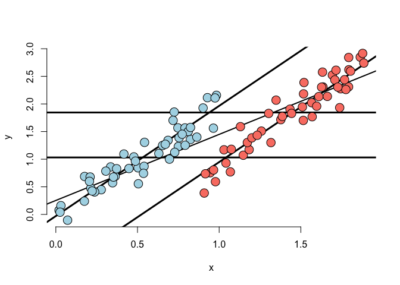

```r
n <- 100; t <- rep(c(0, 1), c(n/2, n/2)); x <- c(runif(n/2), .9 + runif(n/2));
beta0 <- 0; beta1 <- 2; tau <- -1; sigma <- .2
y <- beta0 + x * beta1 + t * tau + rnorm(n, sd = sigma)
plot(x, y, type = "n", frame = FALSE)
abline(lm(y ~ x), lwd = 2)
abline(h = mean(y[1 : (n/2)]), lwd = 3)
abline(h = mean(y[(n/2 + 1) : n]), lwd = 3)
fit <- lm(y ~ x + t)
abline(coef(fit)[1], coef(fit)[2], lwd = 3)
abline(coef(fit)[1] + coef(fit)[3], coef(fit)[2], lwd = 3)
points(x[1 : (n/2)], y[1 : (n/2)], pch = 21, col = "black", bg = "lightblue", cex = 2)
points(x[(n/2 + 1) : n], y[(n/2 + 1) : n], pch = 21, col = "black", bg = "salmon", cex = 2)
```

- Marginal association has red group higher than blue.
- Adjusted relationship has blue group higher than red.
- Group status related to X.
- There is some direct evidence for comparing red and blue holding X fixed.

## Fourth Simulation

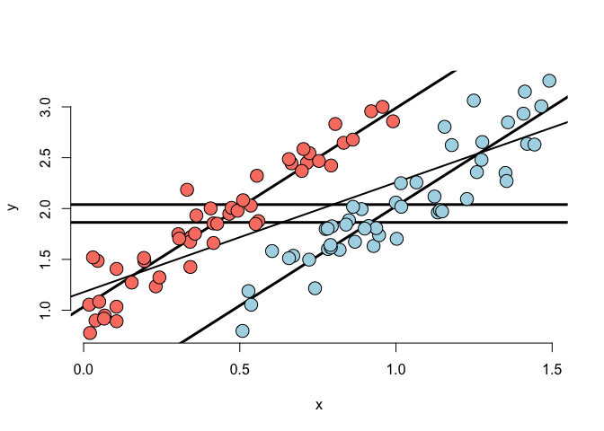

```r
n <- 100; t <- rep(c(0, 1), c(n/2, n/2)); x <- c(.5 + runif(n/2), runif(n/2));
beta0 <- 0; beta1 <- 2; tau <- 1; sigma <- .2
y <- beta0 + x * beta1 + t * tau + rnorm(n, sd = sigma)
plot(x, y, type = "n", frame = FALSE)
abline(lm(y ~ x), lwd = 2)
abline(h = mean(y[1 : (n/2)]), lwd = 3)
abline(h = mean(y[(n/2 + 1) : n]), lwd = 3)
fit <- lm(y ~ x + t)
abline(coef(fit)[1], coef(fit)[2], lwd = 3)
abline(coef(fit)[1] + coef(fit)[3], coef(fit)[2], lwd = 3)
points(x[1 : (n/2)], y[1 : (n/2)], pch = 21, col = "black", bg = "lightblue", cex = 2)
points(x[(n/2 + 1) : n], y[(n/2 + 1) : n], pch = 21, col = "black", bg = "salmon", cex = 2)
```